# Week 5: Lab - Word Cloud Chapter Challenge

Alex Koener

2/14/21

# Instructions

Create a word cloud using the `text` column from a real twitter dataset (sample.csv).

```r
# Add your library below.

library(dplyr)
library(tm)
library(wordcloud)
```

# Step 1. Load and Clean the Data

Load in the `sample.csv` dataset from this project’s data folder. Please make sure you transform the document to lowercase, delete stopwords & numbers & punctuation (1 point).

```r
# Write your code below.

## Read twitter data file then examine.
csv <- read.csv("data/sample.csv", stringsAsFactors = F)
#str(text)

## Create df for the tweets.
text <- csv$text

## Put tweets into a vector then examine.
words_vec <- VectorSource(text)
#head(words_vec)

## Put tweets in vector into a corpus then examine.
words_corpus <- Corpus(words_vec)
#words_corpus
#words_corpus[[1]]
#words_corpus[[1]][1]

## Clean the corpus then examine.
words_corpus <- tm_map(words_corpus, content_transformer(tolower))
words_corpus <- tm_map(words_corpus, removePunctuation)
words_corpus <- tm_map(words_corpus, removeNumbers)
words_corpus <- tm_map(words_corpus, removeWords, stopwords("english"))
```

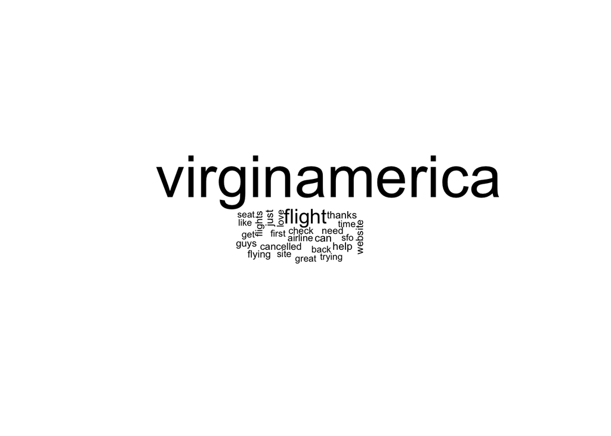

```r
#words_corpus
#words_corpus[[1]]
#words_corpus[[1]][1]

## Create TDM, matrix, word counts; then order the words in decreasing order.
words_tdm <- TermDocumentMatrix(words_corpus)
words_m <- as.matrix(words_tdm)
wordCounts <- rowSums(words_m)
wordCounts <- sort(wordCounts, decreasing = T)
#head(wordCounts)


### Plot wordcloud
wordcloud(names(wordCounts), wordCounts, max.words = 25)
```

# Step 2. Adjust the Stopwords

Add “can” and “just” to the stopwords list (1 point).

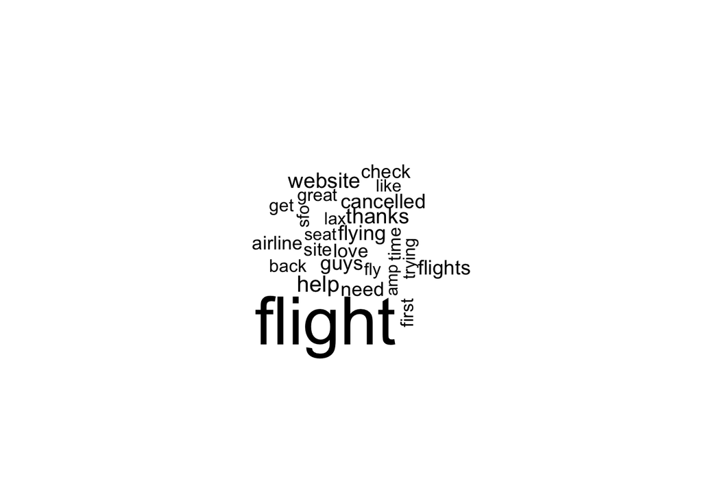

```r
# Write your code below.

## Create stop vector for english stopwords and new stopwords.
stops <- c(stopwords("en"),"can","just", "virginamerica") # Added flights twitter handle (@).
#str(stops)

## Update wordcloud data.
words_corpus <- tm_map(words_corpus, removeWords, stops)
words_tdm <- TermDocumentMatrix(words_corpus)
words_m <- as.matrix(words_tdm)
wordCounts <- rowSums(words_m)
wordCounts <- sort(wordCounts, decreasing = T)

## Plot wordcloud again.
wordcloud(names(wordCounts), wordCounts, max.words = 25)
```

# Step 3. Adjust the Theme

Use five colors and “Accent” for color theme (1 point).

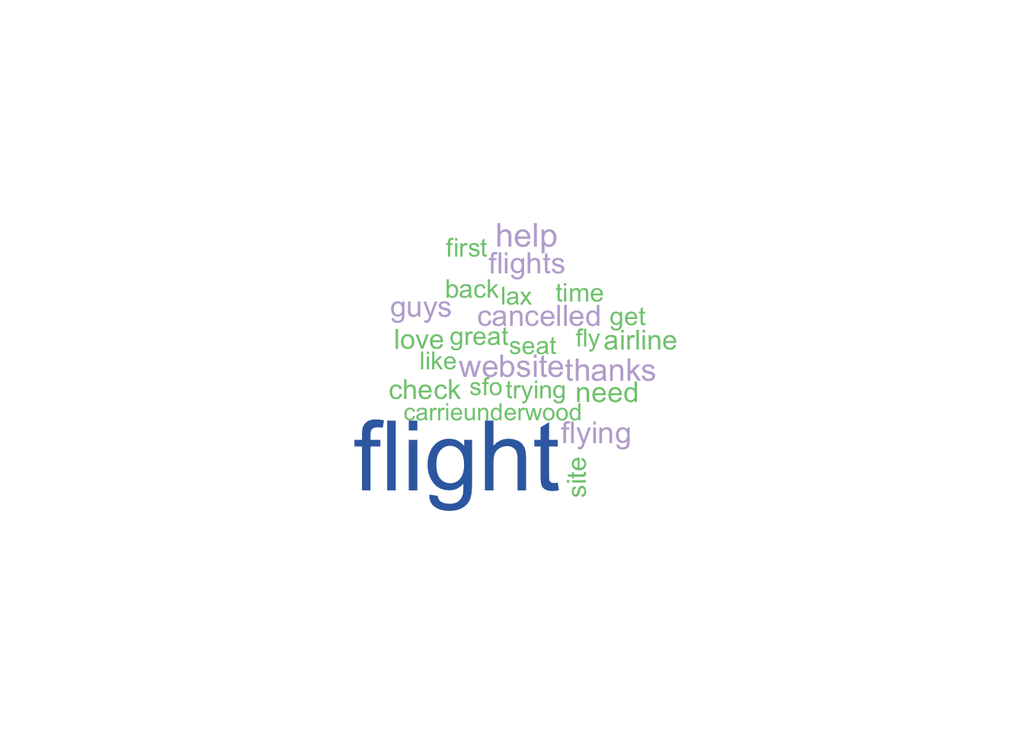

```r
# Write your code below.

## Add color to word cloud.
wordcloud(names(wordCounts), wordCounts, max.words = 25, colors=brewer.pal(5, "Accent"))
```

# Step 4. Analysis

Does the word cloud convey the key points of the document? (1 point).

> When completing the lab by the instructions orginially, a small wordcloud that only had 1 or 2 colors was the result. This wordcloud did not give any insight because all the words had virtually the same size and color, no way to distinguish between each.

> After addding “virginamerica” to my stopword vector (~ line 80), I could eaily see the rest of the words that were over shadowed within the tweets.

> Once we achieved the final word cloud, it’s no suprise that ‘flight’ was the most frequent word used, and some runner-ups being ‘thanks’, ‘website’, and ‘help’. This word cloud made it very easy for us to understand the word frequencies and how they differ.

# Step 5. Compile

Submit the compiled file. The wordcloud may prevent you from compiling. If so, do the following:

```
jpeg('p1.jpg')
wordcloud(cloudFrame.t$word, cloudFrame.t$freq)
dev.off()
```

This will make the graphs save in the current working directory.

```r
# Write your code below, if necessary.
```